# Capstone_ML_DiseasePrediction_Group4_Pinki_Shruti_Umiama

### DSC672

### Group 4

### Project: Disease Prediction

### Umiama Khurshid Ahmad, Shruti Shah and Pinki Sharma

### uahmad4@depaul.edu, Psharm14@depaul.edu, sshah121@depaul.edu

### Project Description :

Our aim for this project is to create a platform that can help doctors in disease diagnosis. We belive our system will help doctors to aid thier decision-making abilities for disease diagnosis.

```python
%pip install xgboost
```

```python
%pip install sklearn-pandas
```

```python
%pip install prince
```

```python
%pip install Flask
```

```python
%pip install kmodes
```

```python
%pip install -U imbalanced-learn
```

```python
#from google.colab import drive
#drive.mount('/content/drive')
```

**Import Libraries**

```python
#Standard Imports
import pandas as pd
import numpy as np
import prince
#For vizualtions
import matplotlib as mpl
import matplotlib.pyplot as plt
import seaborn as sns

# For Flask
import os
import pickle
```

### These are the packages we used

```python
#For transformations
from sklearn.preprocessing import LabelEncoder, OneHotEncoder, StandardScaler, MinMaxScaler
from sklearn import preprocessing

# Modeling Evaluation
from sklearn.model_selection import train_test_split
from sklearn import metrics
from sklearn.tree import DecisionTreeClassifier
from sklearn.ensemble import RandomForestClassifier
from sklearn.ensemble import GradientBoostingClassifier
import xgboost as xgb

# Pipelines
from sklearn.pipeline import Pipeline, FeatureUnion
from sklearn.base import BaseEstimator, TransformerMixin
from sklearn.compose import ColumnTransformer
#from sklearn.feature_extraction.text import TfidfVectorizer
#from sklearn_pandas import DataFrameMapper
from sklearn.model_selection import GridSearchCV

from sklearn.decomposition import PCA
from sklearn.metrics import accuracy_score
from sklearn.metrics import confusion_matrix, classification_report
from sklearn.model_selection import cross_val_score

# To run flask
from flask import Flask, render_template, request
```

**Here are what the columns represent:**

- Disease (categorical) : name of the diseases
- Disease_CUI (numeric) : disease id
- Symptoms (categorical) : name of the symptoms
- Symptoms_CUI (numeric) : symptom id
- Weight (numeric) : weight of the person in lbs
- Height (numeric) : hight of the person in cm
- Intensity (categorical ) : how intense is the pain (low, medium, high)
- Severity (categorical) : severity of the symptoms (low, medium, high)
- Age (numeric) : age of the person
- Gender (categorical) : gender of the person
- BMI_Level (numeric) : BMI level of the person
- Region (categorical) : what part of the region does the person belongs to
- Season (categorical) : season(summer, winter,fall)

### Get the Data

#### Use pandas to read in the datasets as a dataframe.

```python
df = pd.read_csv("OHAS_Dataset.csv")
```

```python
#first look of Dataset
display(df.sample(5))
```

|  | Disease | Disease_CUI | Symptoms | Symptom_CUI | Weight | Height | Intensity | Severity | Age | Gender | BMI_Level | Region | Season |
| --- | --- | --- | --- | --- | --- | --- | --- | --- | --- | --- | --- | --- | --- |
| 1834 | suicide attempt | C3888977 | halluci162tions auditory | C0028081 | 114 | 162 | low | high | 49 | male | 26.125 | southeast | Summer |
| 2115 | overload fluid | C0085669 | drowsiness | C1706559 | 144 | 162 | medium | medium | 17 | female | 25.850 | southeast | Summer |
| 1750 | delusion | C0020258 | catatonia | C0040264 | 56 | 162 | low | high | 21 | male | 27.835 | southeast | Summer |
| 363 | malig162nt neoplasm of prostate | C0023788 | orthostasis | C0340464 | 163 | 198 | medium | high | 19 | female | 26.400 | southwest | Summer |
| 910 | biliary calculus | C0011848 | apyrexial | C0032617 | 61 | 173 | low | medium | 23 | male | 28.310 | northwest | Summer |

```python
df.shape
```

```
(2129, 13)
```

The dataset has 2129 rows and 13 columns.

#### Checking the data and investigating the column types.

```python
df.info()
```

```
<class 'pandas.core.frame.DataFrame'>
RangeIndex: 2129 entries, 0 to 2128
Data columns (total 13 columns):
 #   Column       Non-Null Count  Dtype
---  ------       --------------  -----
 0   Disease      2129 non-null   object
 1   Disease_CUI  2119 non-null   object
 2   Symptoms     2127 non-null   object
 3   Symptom_CUI  2129 non-null   object
 4   Weight       2129 non-null   int64
 5   Height       2129 non-null   int64
 6   Intensity    2127 non-null   object
 7   Severity     2128 non-null   object
 8   Age          2129 non-null   int64
 9   Gender       2129 non-null   object
 10  BMI_Level    2129 non-null   float64
 11  Region       2129 non-null   object
 12  Season       2129 non-null   object
dtypes: float64(1), int64(3), object(9)
memory usage: 216.4+ KB
```

Dataset has 6 categorical data and 4 numeric data and target variable(Disease) multiclass label categorical variable. Disease_CUI and Symptom_CUI is unique ID are each disease and symptoms.

```python
df.columns
```

```
Index(['Disease', 'Disease_CUI', 'Symptoms', 'Symptom_CUI', 'Weight', 'Height',
       'Intensity', 'Severity', 'Age', 'Gender', 'BMI_Level', 'Region',
       'Season'],
      dtype='object')
```

```python
df.Disease.unique() #unique diseases
```

```
array(['influenza', 'gastritis', 'hypercholesterolemia', 'epilepsy',
       'insufficiency re162l', 'dehydration', 'hypothyroidism',
       'hernia hiatal', 'fibroid tumor', 'deglutition disorder',
       'osteoporosis', 'chronic alcoholic intoxication', 'asthma',
       'sepsis (invertebrate)', 'paranoia', 'ileus', 'neoplasm',
       'obesity morbid', 'primary malig162nt neoplasm', 'failure heart',
       'malig162nt neoplasm of breast', 'tonic-clonic epilepsy',
       'transient ischemic attack', 'malig162nt neoplasm of prostate',
       'embolism pulmo162ry', 'tricuspid valve insufficiency',
       'respiratory failure', 'degenerative polyarthritis', 'aphasia',
       'neoplasm metastasis', 'malig162nt tumor of colon', 'lymphoma',
       'anemia', 'chronic obstructive airway disease',
       'sickle cell anemia', 'coro162ry arteriosclerosis',
       'cholecystitis', 'psychotic disorder', 'thrombus',
       'chronic kidney failure', 'depressive disorder',
       'myocardial infarction', 'obesity', 'infection uri162ry tract',
       'tachycardia sinus', 'gout', 'hyperglycemia', 'diverticulosis',
       'failure kidney', 'schizophrenia', 'decubitus ulcer',
       'encephalopathy', 'affect labile', 'carcinoma prostate',
       "Alzheimer's disease", 'incontinence', 'hyperbilirubinemia',
       'paroxysmal dyspnea', 'bipolar disorder', 'hepatitis',
       'pericardial effusion body substance', 'adhesion',
       'biliary calculus', 'endocarditis',
       'acquired immuno-deficiency syndrome', 'pneumothorax',
       'accident cerebrovascular', 'confusion', 'candidiasis',
       'anxiety state', 'cirrhosis', 'pancytopenia', 'oral candidiasis',
       'diverticulitis', 'spasm bronchial', 'ulcer peptic',
       'depression mental', 'emphysema pulmo162ry', 'hypoglycemia',
       'dependence', 'osteomyelitis', 'hemorrhoids',
       'primary carcinoma of the liver cells', 'pyelonephritis',
       'pancreatitis', 'cholelithiasis', 'cardiomyopathy',
       'Pneumocystis carinii pneumonia', 'carcinoma colon',
       'edema pulmo162ry', 'carcinoma breast', 'hemiparesis',
       'mitral valve insufficiency', 'peripheral vascular disease',
       'tonic-clonic seizures', 'effusion pericardial',
       'thrombocytopaenia', 'adenocarcinoma', 'failure heart congestive',
       'exanthema', 'ischemia', 'hypertension pulmo162ry', 'infection',
       'cellulitis', 'lymphatic diseases', 'gastroenteritis',
       'parkinson disease', 'hernia', 'kidney disease', 'colitis',
       'deep vein thrombosis', 'perso162lity disorder', 'hyperlipidemia',
       'pneumonia', 'gastroesophageal reflux disease',
       'pneumonia aspiration', 'stenosis aortic valve',
       'hypertensive disease', 'glaucoma', 'septicemia', 'bronchitis',
       'delusion', 'upper respiratory infection', 'dementia',
       'ketoacidosis diabetic ', 'manic disorder', 'suicide attempt',
       'hiv infections', 'benign prostatic hypertrophy', 'HIV',
       'bacteremia', 'neutropenia', 'hepatitis B', 'hepatitis C',
       'coro162ry heart disease', 'carcinoma of lung', 'arthritis',
       'malig162nt neoplasm of lung', 'carcinoma', 'delirium', 'melanoma',
       'kidney failure acute', 'diabetes', 'systemic infection',
       'malig162nt neoplasms', 'neuropathy', 'overload fluid',
       'migraine disorders'], dtype=object)
```

```python
df.Symptoms.unique().size
```

```
405
```

There are about 405 unique symptoms.

#### Replacing "162" into "na" for both Symptoms and Disease

```python
# replacing "162" into "na" for symptoms
df['Symptoms'].replace('\d+','na',inplace=True,regex=True)
df
```

|  | Disease | Disease_CUI | Symptoms | Symptom_CUI | Weight | Height | Intensity | Severity | Age | Gender | BMI_Level | Region | Season |
| --- | --- | --- | --- | --- | --- | --- | --- | --- | --- | --- | --- | --- | --- |
| 0 | influenza | C0162565 | uncoordination | C0039239 | 68 | 180 | high | medium | 24 | female | 27.900 | southwest | Summer |
| 1 | influenza | C0162565 | fever | C0000737 | 68 | 170 | low | medium | 23 | male | 33.770 | southeast | Summer |
| 2 | influenza | C0162565 | pleuritic pain | C0235704 | 68 | 162 | low | low | 24 | male | 33.000 | southeast | Summer |
| 3 | influenza | C0162565 | snuffle | C0030554 | 68 | 162 | high | medium | 34 | male | 22.705 | northwest | Summer |
| 4 | influenza | C0162565 | throat sore | C0030552 | 68 | 185 | low | high | 21 | male | 28.880 | northwest | Winter |
| ... | ... | ... | ... | ... | ... | ... | ... | ... | ... | ... | ... | ... | ... |
| 2124 | migraine disorders | C0020532 | dizziness | C0005959 | 61 | 162 | high | high | 20 | male | 38.170 | northwest | Summer |
| 2125 | migraine disorders | C0020532 | numbness | C0031256 | 61 | 173 | low | low | 20 | female | 36.860 | northeast | Summer |
| 2126 | migraine disorders | C0020532 | nausea | C0014591 | 61 | 168 | high | high | 24 | female | 32.395 | southwest | Winter |
| 2127 | migraine disorders | C0020532 | fever | C0025323 | 61 | 168 | medium | medium | 17 | male | 42.750 | southeast | Winter |
| 2128 | migraine disorders | C0020532 | splenomegaly | C0015967 | 61 | 168 | high | high | 17 | male | 25.080 | northeast | Winter |

2129 rows × 13 columns

```python
#replacing "162" from word into "na" for Disease column
df['Disease'].replace('\d+','na',inplace=True,regex=True)
df
```

|  | Disease | Disease_CUI | Symptoms | Symptom_CUI | Weight | Height | Intensity | Severity | Age | Gender | BMI_Level | Region | Season |
| --- | --- | --- | --- | --- | --- | --- | --- | --- | --- | --- | --- | --- | --- |
| 0 | influenza | C0162565 | uncoordination | C0039239 | 68 | 180 | high | medium | 24 | female | 27.900 | southwest | Summer |
| 1 | influenza | C0162565 | fever | C0000737 | 68 | 170 | low | medium | 23 | male | 33.770 | southeast | Summer |
| 2 | influenza | C0162565 | pleuritic pain | C0235704 | 68 | 162 | low | low | 24 | male | 33.000 | southeast | Summer |
| 3 | influenza | C0162565 | snuffle | C0030554 | 68 | 162 | high | medium | 34 | male | 22.705 | northwest | Summer |
| 4 | influenza | C0162565 | throat sore | C0030552 | 68 | 185 | low | high | 21 | male | 28.880 | northwest | Winter |
| ... | ... | ... | ... | ... | ... | ... | ... | ... | ... | ... | ... | ... | ... |
| 2124 | migraine disorders | C0020532 | dizziness | C0005959 | 61 | 162 | high | high | 20 | male | 38.170 | northwest | Summer |
| 2125 | migraine disorders | C0020532 | numbness | C0031256 | 61 | 173 | low | low | 20 | female | 36.860 | northeast | Summer |
| 2126 | migraine disorders | C0020532 | nausea | C0014591 | 61 | 168 | high | high | 24 | female | 32.395 | southwest | Winter |
| 2127 | migraine disorders | C0020532 | fever | C0025323 | 61 | 168 | medium | medium | 17 | male | 42.750 | southeast | Winter |
| 2128 | migraine disorders | C0020532 | splenomegaly | C0015967 | 61 | 168 | high | high | 17 | male | 25.080 | northeast | Winter |

2129 rows × 13 columns

```python
#How many dieases with frequency -- maybe we can search on top ones and make others column of those which has frequency less
df.groupby('Disease').count().reset_index()
```

|  | Disease | Disease_CUI | Symptoms | Symptom_CUI | Weight | Height | Intensity | Severity | Age | Gender | BMI_Level | Region | Season |
| --- | --- | --- | --- | --- | --- | --- | --- | --- | --- | --- | --- | --- | --- |
| 0 | Alzheimer's disease | 18 | 18 | 18 | 18 | 18 | 18 | 18 | 18 | 18 | 18 | 18 | 18 |
| 1 | HIV | 15 | 14 | 15 | 15 | 15 | 15 | 15 | 15 | 15 | 15 | 15 | 15 |
| 2 | Pneumocystis carinii pneumonia | 18 | 18 | 18 | 18 | 18 | 18 | 18 | 18 | 18 | 18 | 18 | 18 |
| 3 | accident cerebrovascular | 8 | 8 | 8 | 8 | 8 | 8 | 8 | 8 | 8 | 8 | 8 | 8 |
| 4 | acquired immuno-deficiency syndrome | 15 | 14 | 15 | 15 | 15 | 15 | 15 | 15 | 15 | 15 | 15 | 15 |
| ... | ... | ... | ... | ... | ... | ... | ... | ... | ... | ... | ... | ... | ... |
| 143 | tonic-clonic seizures | 17 | 17 | 17 | 17 | 17 | 17 | 17 | 17 | 17 | 17 | 17 | 17 |
| 144 | transient ischemic attack | 17 | 17 | 17 | 17 | 17 | 17 | 17 | 17 | 17 | 17 | 17 | 17 |
| 145 | tricuspid valve insufficiency | 10 | 10 | 10 | 10 | 10 | 10 | 10 | 10 | 10 | 10 | 10 | 10 |
| 146 | ulcer peptic | 12 | 12 | 12 | 12 | 12 | 12 | 12 | 12 | 12 | 12 | 12 | 12 |
| 147 | upper respiratory infection | 28 | 28 | 28 | 28 | 28 | 28 | 28 | 28 | 28 | 28 | 28 | 28 |

148 rows × 13 columns

In total of 148 diseases

```python
print('Number diseases:', df.Disease.nunique())
df.groupby('Disease').size().sort_values(ascending = False)
```

```
Number diseases: 148
```

```
Disease
upper respiratory infection    28
bipolar disorder               28
psychotic disorder             25
malignant neoplasms            25
anxiety state                  24
                               ..
accident cerebrovascular        8
failure heart congestive        7
migraine disorders              7
kidney disease                  6
decubitus ulcer                 3
Length: 148, dtype: int64
```

# Data Visualization

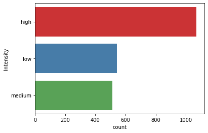

```python
sns.countplot(y='Intensity', data=df, palette="Set1")
```

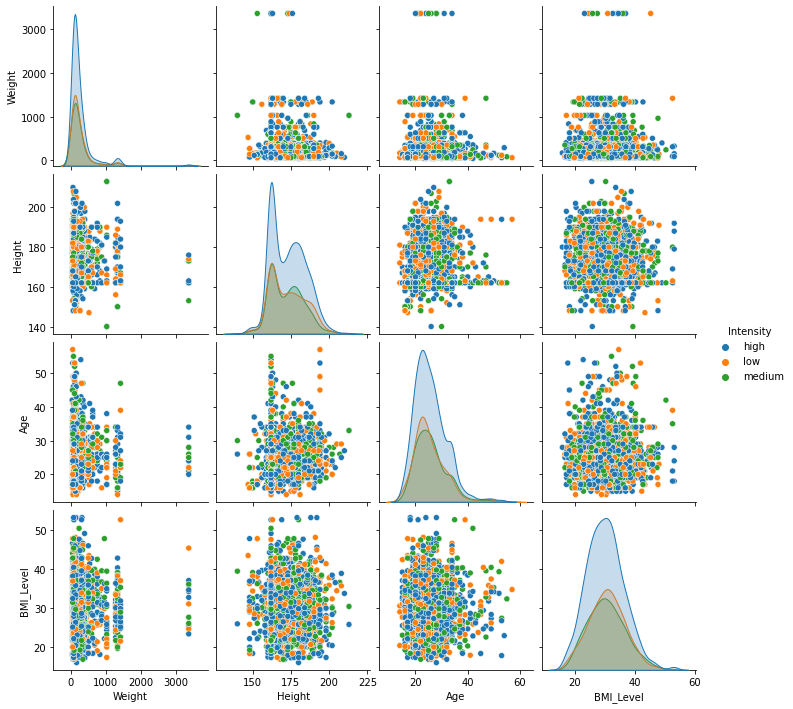

```python
df_pairplot = sns.pairplot(df,hue='Intensity')
```

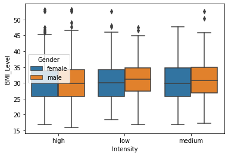

```python
#sns.stripplot(x='Intensity', y= 'BMI_Level', hue='Gender',data = df,jitter = True)
sns.boxplot(x='Intensity',y='BMI_Level',data=df,hue='Gender')
```

```python
print('Number diseases:', df.Disease.nunique())
df.groupby('Disease').size().sort_values(ascending = False)
```

```
Number diseases: 148
```

```
Disease
upper respiratory infection    28
bipolar disorder               28
psychotic disorder             25
malignant neoplasms            25
anxiety state                  24
                               ..
accident cerebrovascular        8
failure heart congestive        7
migraine disorders              7
kidney disease                  6
decubitus ulcer                 3
Length: 148, dtype: int64
```

```python
df_copy = pd.read_csv('OHAS_Dataset.csv')
top_5 = ['upper respiratory infection','psychotic disorder','chronic kidney failure',\
          'malignant neoplasms', 'bipolar disorder','anxiety state']

# make a new column with duplicated data
df_copy['Disease'] = df_copy['Disease'].copy()

# replace all specialties not in top 10 with 'Other' category
df_copy.loc[~df_copy.Disease.isin(top_5),'Disease'] = 'Other'
```

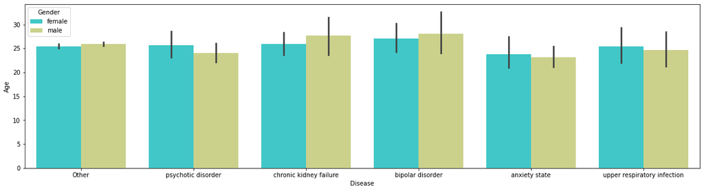

```python
plt.figure(figsize=(20,5))
sns.barplot(x='Disease',y='Age',data=df_copy, palette='rainbow', hue='Gender')
```

General distribution of Age and BMI in order to see the variations of these two sepratelay

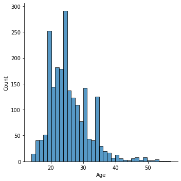

```python
sns.displot(df.Age)
```

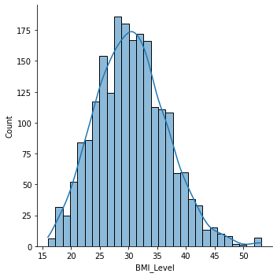

```python
sns.displot(df.BMI_Level,kde=True)
```

The healthy bmi level is between 19 to 21. We can exmine an obesity level as BMI is greater than 25 for majority of the data, its somewhat normaily distributed

- All the dieases to people older than 40
- Which dieases has symptoms of fever
- High intensity to male and females ratio
- What are the common dieases with ibnormal BMI and have high severity to older age

```python
dieases_on_older_people = df.loc[(df_copy['Age'] > 40)]
```

```python
dflistSymptoms = df['Symptoms'].str.split()
diseases_wd_fever = df.loc[df['Symptoms'] == 'fever']
diseases_wd_fever['Disease']
```

```
1                                 influenza
78                              dehydration
141                           fibroid tumor
199                   sepsis (invertebrate)
387           tricuspid valve insufficiency
451                                lymphoma
583                  chronic kidney failure
644                 infection urinary tract
734                         decubitus ulcer
798                     Alzheimer's disease
873                               hepatitis
928     acquired immuno-deficiency syndrome
1069                         diverticulitis
1088                        spasm bronchial
1174                          osteomyelitis
```

[output cut: 25 more lines]

```python
sr_people_with_high_intensity = df.loc[(df['Age'] < 40) & (df['Severity'] == 'high') & (df['Intensity'] == 'high')]
print('Number diseases:', sr_people_with_high_intensity.Disease.nunique())
#sr_people_with_high_intensity.groupby('Disease').size().sort_values(ascending = False)
```

```
Number diseases: 145
```

```python
top_5 = ['upper respiratory infection','psychotic disorder','chronic kidney failure',\
          'malignant neoplasms', 'malignant neoplasm of prostate']

# make a new column with duplicated data
sr_people_with_high_intensity['Disease'] = sr_people_with_high_intensity['Disease'].copy()

# replace all specialties not in top 10 with 'Other' category
sr_people_with_high_intensity.loc[~sr_people_with_high_intensity.Disease.isin(top_5),'Disease'] = 'Other'
```

```python
sr_people_with_high_intensity.groupby('Disease').size()
```

```
Disease
Other                             478
chronic kidney failure              8
malignant neoplasm of prostate      8
malignant neoplasms                 8
psychotic disorder                  8
upper respiratory infection         9
dtype: int64
```

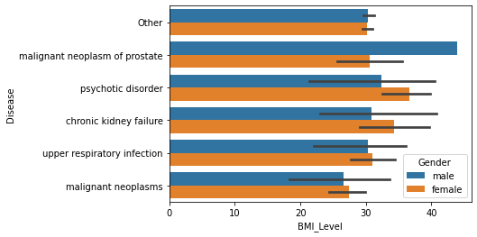

```python
sns.barplot(y='Disease',x='BMI_Level',hue='Gender',data=sr_people_with_high_intensity)
```

### Checking for any missing values

```python
#checking for Nas
df.isna().sum()
```

```
Disease         0
Disease_CUI    10
Symptoms        2
Symptom_CUI     0
Weight          0
Height          0
Intensity       2
Severity        1
Age             0
Gender          0
BMI_Level       0
Region          0
Season          0
dtype: int64
```

We can see that our dataset is not clean and has missing values in columns: Intensity, Severity, Symptoms, Disease_CUI

**Removing the missing values**

```python
#adjusting Nas, - > as its not numeric we will remove these for now.
df.dropna(inplace=True)
```

```python
df.isna().sum()
```

```
Disease        0
Disease_CUI    0
Symptoms       0
Symptom_CUI    0
Weight         0
Height         0
Intensity      0
Severity       0
Age            0
Gender         0
BMI_Level      0
Region         0
Season         0
dtype: int64
```

```python
df.shape
```

```
(2114, 13)
```

#### Drooping insignificant columns: Region, Symtom_CUI, Disease_CUI and Season

```python
df = df.drop(['Region', 'Symptom_CUI', 'Disease_CUI', 'Season'], axis=1)
df
```

|  | Disease | Symptoms | Weight | Height | Intensity | Severity | Age | Gender | BMI_Level |
| --- | --- | --- | --- | --- | --- | --- | --- | --- | --- |
| 0 | influenza | uncoordination | 68 | 180 | high | medium | 24 | female | 27.900 |
| 1 | influenza | fever | 68 | 170 | low | medium | 23 | male | 33.770 |
| 2 | influenza | pleuritic pain | 68 | 162 | low | low | 24 | male | 33.000 |
| 3 | influenza | snuffle | 68 | 162 | high | medium | 34 | male | 22.705 |
| 4 | influenza | throat sore | 68 | 185 | low | high | 21 | male | 28.880 |
| ... | ... | ... | ... | ... | ... | ... | ... | ... | ... |
| 2124 | migraine disorders | dizziness | 61 | 162 | high | high | 20 | male | 38.170 |
| 2125 | migraine disorders | numbness | 61 | 173 | low | low | 20 | female | 36.860 |
| 2126 | migraine disorders | nausea | 61 | 168 | high | high | 24 | female | 32.395 |
| 2127 | migraine disorders | fever | 61 | 168 | medium | medium | 17 | male | 42.750 |
| 2128 | migraine disorders | splenomegaly | 61 | 168 | high | high | 17 | male | 25.080 |

2114 rows × 9 columns

After identifying list of unique disease, we tried to combine disease that give same meaning for eg: malignant neoplasms and malignant neoplasm of prostate then named it as malignant neoplasm. Similarly, all disease related to heart named as heart disease.

```python
predf = pd.read_csv("dataset_preprocessed.csv",header=None)
```

```python
predf
dict_s ={}
for i in range(0,(predf[0].count())):
  listOfdisease = predf[0][i].split("+")
  dict_s[predf[1][i]] = listOfdisease
print(dict_s)
```

```
{'malignant neoplasms': ['malignant neoplasms', 'malignant neoplasm of prostate', 'neoplasm metastasis', 'primary malignant neoplasm'], 'Cancer': ['carcinoma prostate ', ' carcinoma ', ' adenocarcinoma', 'lymphoma', 'neoplasm'], 'heart disease': ['pericardial effusion body substance', 'ischemia', 'c…
```

```python
pd.options.mode.chained_assignment = None  # default='warn'
```

```python
#print(df.head(25))
for i in range (0,(df["Disease"].count())):
  dis = df.iloc[i,0]
  #print(dis)
  for key,val in dict_s.items():
    remove_space = [x.replace(' ','') for x in val]
    if dis.replace(' ','') in remove_space:
      #print(dis,val)
      df.iloc[i,0] = key
df.to_csv("joined.csv")
```

After combining disease of same characteristic, we looked inside Symptoms columns, we rename some of the symptoms. For instance, there were two symptoms chest pain and pain chest, then we rename pain chest into chest pain, so that while using one hot encoding will not create extra columns for similar symptoms(same meaning symptoms). Finally created a new dataset called combined dataset.

### EDA for further anlysing the relation between variables.

#### **Multiple Correspondence analysis**

##### To check how categorical variables are related.

```python
new= pd.read_csv("combined_dataset.csv")
# new dataframe by dropping insignificant colums and numeric columns
new = new.drop(['Weight', 'Height', 'Season', 'Intensity', 'Gender', 'Age', 'Severity'], axis=1)
new.columns = ['Disease','Symptoms']
print(new.head())
```

```
     Disease        Symptoms
0  influenza  uncoordination
1  influenza           fever
2  influenza  pleuritic pain
3  influenza         snuffle
4  influenza     throat sore
```

```python
new.Disease.value_counts().sort_values(ascending=False).head(10)
```

```
brain disease            158
heart disease            138
respiratory disease       92
Cancer                    85
lung disease              78
malignant neoplasms       69
blood related disease     64
colon disease             58
anxiety                   57
stomach disease           55
Name: Disease, dtype: int64
```

```python
new.isna().sum()
```

```
Disease     0
Symptoms    0
dtype: int64
```

```python
mca= prince.MCA()
mca2 = mca.fit(new)
mca1 = mca2.transform(new)
print(mca1)
```

```
             0         1
0    -0.046264  0.237546
1    -0.254917  0.195965
2    -0.279576  0.169384
3    -0.342053  0.155397
4    -0.233795  0.988890
...        ...       ...
2109  0.013492 -0.400143
2110  0.260283 -0.767558
2111 -0.236071  0.151016
2112 -0.060509 -0.047925
2113 -0.232431  0.090939

[2114 rows x 2 columns]
```

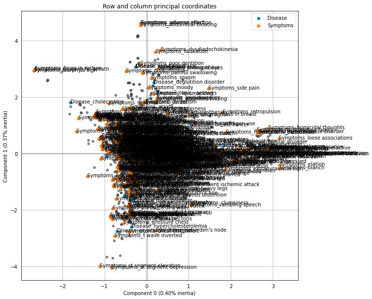

```python
# plotting
p= mca2.plot_coordinates(X = new, row_points_size=20, figsize=(10,10), show_column_labels = True);
```

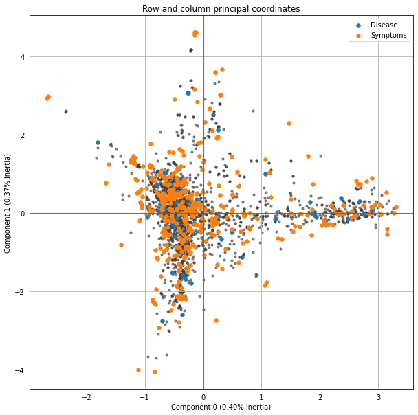

```python
# plotting
p= mca2.plot_coordinates(X = new, row_points_size=10, figsize=(10,10), show_column_labels = False);
```

From both the plot, it's not clear to interpret and analysize as we have multiclass label and figure is vague. One disease have multiple symptoms so figure is unclear, however we can see some grouping of similar symptoms that predict disease are together.

```python
mca.eigenvalues_
```

```
[0.9067345830614689, 0.8464791450587204]
```

```python
mca.total_inertia_
```

```
229.5
```

```python
mca.explained_inertia_
```

```
[0.003950913215954113, 0.0036883622878375612]
```

#### **KModes**

Performing KModes to cluster categorical variables.

```python
df= pd.read_csv("combined_dataset.csv")
X = df.drop(['Disease'],axis=1)
y = df.Disease
```

Implementing Elbow method to check how many clusters to use.

[output not shown]

[output cut: 37 more lines]

[output not shown]

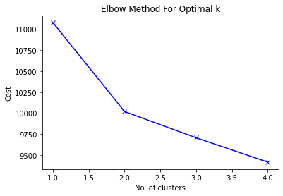

```python
from kmodes.kmodes import KModes
# Elbow curve to find optimal K
sum_of_dissimilarity = []      #between the clusters
K = range(1,5)
for num_clusters in list(K):
    kmode = KModes(n_clusters=num_clusters, init = "random", n_init = 5, verbose=1)
    kmode.fit_predict(X)
    sum_of_dissimilarity.append(kmode.cost_)

plt.plot(K, sum_of_dissimilarity, 'bx-')
plt.xlabel('No. of clusters')
plt.ylabel('Cost')
plt.title('Elbow Method For Optimal k')
```

```python
# Building the model with 3 clusters
kmode = KModes(n_clusters=3, init = "random", n_init = 5, verbose=1)
clusters = kmode.fit_predict(X)
clusters
```

[output not shown]

```
array([0, 1, 1, ..., 0, 1, 2], dtype=uint16)
```

```python
#insert the predicted cluster values in our original dataset.
X.insert(0, "Cluster", clusters, True)
X
```

|  | Cluster | Symptoms | Weight | Height | Intensity | Severity | Age | Gender | Season |
| --- | --- | --- | --- | --- | --- | --- | --- | --- | --- |
| 0 | 0 | uncoordination | 68 | 180 | high | medium | 24 | female | Summer |
| 1 | 1 | fever | 68 | 170 | low | medium | 23 | male | Summer |
| 2 | 1 | pleuritic pain | 68 | 162 | low | low | 24 | male | Summer |
| 3 | 1 | snuffle | 68 | 162 | high | medium | 34 | male | Summer |
| 4 | 1 | throat sore | 68 | 185 | low | high | 21 | male | Winter |
| 5 | 1 | malaise | 68 | 185 | medium | medium | 21 | female | Winter |
| 6 | 1 | debilitation | 68 | 185 | medium | medium | 25 | female | Winter |
| 7 | 0 | asthenia | 68 | 185 | low | high | 25 | female | Winter |
| 8 | 1 | chill | 68 | 185 | medium | low | 27 | male | Winter |
| 9 | 0 | scleral icterus | 68 | 185 | high | medium | 27 | female | Winter |
| 10 | 1 | nasal flaring | 68 | 188 | medium | high | 31 | male | Winter |
| 11 | 0 | dysuria | 68 | 188 | medium | low | 31 | female | Winter |
| 12 | 2 | lip smacking | 68 | 188 | high | high | 31 | male | Winter |
| 13 | 0 | headache | 68 | 188 | low | high | 31 | female | Winter |
| 14 | 2 | snore | 68 | 188 | high | high | 33 | male | Winter |
| 15 | 1 | green sputum | 68 | 188 | low | low | 33 | female | Winter |
| 16 | 1 | shortness of breath | 68 | 188 | high | low | 33 | male | Winter |
| 17 | 2 | distress respiratory | 68 | 183 | high | high | 31 | male | Winter |
| 18 | 1 | blackout | 68 | 183 | low | low | 31 | male | Winter |
| 19 | 1 | extreme exhaustion | 68 | 183 | low | medium | 31 | female | Winter |
| 20 | 0 | heme positive | 140 | 183 | high | medium | 31 | female | Winter |
| 21 | 1 | pain abdominal | 140 | 183 | low | low | 33 | male | Winter |
| 22 | 0 | vomiting | 140 | 183 | high | medium | 33 | female | Winter |
| 23 | 2 | disequilibrium | 140 | 183 | high | high | 33 | male | Winter |
| 24 | 0 | nausea | 140 | 183 | high | medium | 33 | female | Winter |
| 25 | 0 | intoxication | 140 | 168 | medium | medium | 18 | female | Summer |
| 26 | 0 | haemorrhage | 140 | 168 | high | high | 18 | female | Summer |
| 27 | 1 | guaiac positive | 140 | 186 | low | low | 26 | male | Winter |
| 28 | 2 | pain | 140 | 162 | high | medium | 26 | male | Summer |
| 29 | 2 | decreased body weight | 140 | 182 | high | high | 22 | male | Winter |

[output cut: 2084 more lines]

```python
y_means = kmode.fit_predict(X)
```

[output not shown]

```python
pd.set_option('display.max_rows', df.shape[0]+1)
#X['Age']
```

```python
X['Age group'] = pd.qcut(X['Age'],4)
X['Height group'] = pd.qcut(X['Height'],4)
X['Weight group'] = pd.qcut(X['Weight'],4)
```

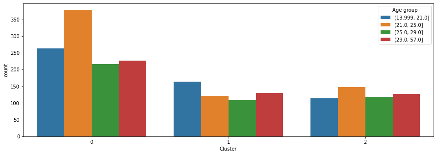

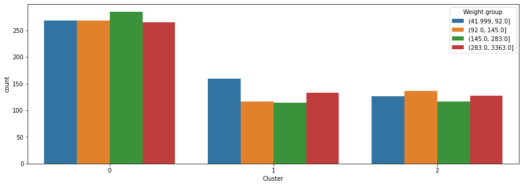

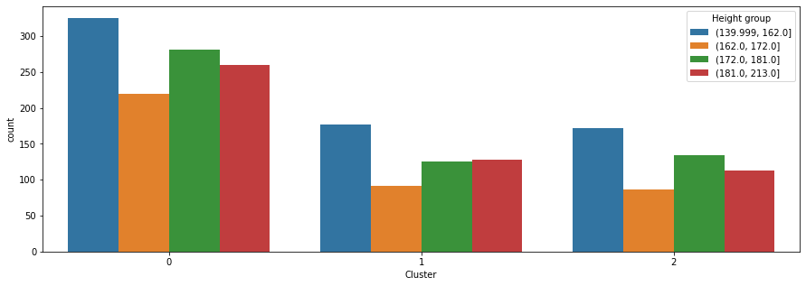

```python
all_features = ["Age group", "Weight group", "Height group"]

for col in all_features:
    plt.subplots(figsize = (15,5))
    sns.countplot(x='Cluster',hue=col, data = X)
    plt.show()
```

The above plot shows model building with KModes using three clusters on categorical variables Age, Weight and Height. The method also group the variables as we can see age being group as between 13-21, 21-25, and so forth.

```python
# performing onehot encoding on variables
categorial_list_OneHot = ['Intensity', 'Severity','Gender']
X_trans =pd.get_dummies(df,columns=categorial_list_OneHot)
```

[output not shown]

[output cut: 47 more lines]

[output not shown]

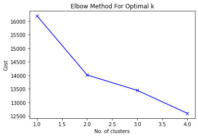

```python
# Implementing KModes on Symptoms variable to see how sysmptoms are clusters together
from kmodes.kmodes import KModes
# Elbow curve to find optimal K
sum_of_dissimilarity = []      #between the clusters
K = range(1,5)
for num_clusters in list(K):
    kmode = KModes(n_clusters=num_clusters, init = "random", n_init = 5, verbose=1)
    kmode.fit_predict(X_trans)
    sum_of_dissimilarity.append(kmode.cost_)

plt.plot(K, sum_of_dissimilarity, 'bx-')
plt.xlabel('No. of clusters')
plt.ylabel('Cost')
plt.title('Elbow Method For Optimal k')
```

```python
# Building the model with 3 clusters
kmode = KModes(n_clusters=2, init = "random", n_init = 5, verbose=1)
clusters = kmode.fit_predict(X_trans)
clusters
```

[output not shown]

```
array([0, 1, 1, ..., 0, 1, 1], dtype=uint16)
```

```python
# inserting the cluster to our dataset
X_trans.insert(0, "Cluster", clusters, True)
X_trans
```

|  | Cluster | Disease | Symptoms | Weight | Height | Age | Season | Intensity_high | Intensity_low | Intensity_medium | Severity_high | Severity_low | Severity_medium | Gender_female | Gender_male |
| --- | --- | --- | --- | --- | --- | --- | --- | --- | --- | --- | --- | --- | --- | --- | --- |
| 0 | 0 | influenza | uncoordination | 68 | 180 | 24 | Summer | 1 | 0 | 0 | 0 | 0 | 1 | 1 | 0 |
| 1 | 1 | influenza | fever | 68 | 170 | 23 | Summer | 0 | 1 | 0 | 0 | 0 | 1 | 0 | 1 |
| 2 | 1 | influenza | pleuritic pain | 68 | 162 | 24 | Summer | 0 | 1 | 0 | 0 | 1 | 0 | 0 | 1 |
| 3 | 1 | influenza | snuffle | 68 | 162 | 34 | Summer | 1 | 0 | 0 | 0 | 0 | 1 | 0 | 1 |
| 4 | 1 | influenza | throat sore | 68 | 185 | 21 | Winter | 0 | 1 | 0 | 1 | 0 | 0 | 0 | 1 |
| 5 | 0 | influenza | malaise | 68 | 185 | 21 | Winter | 0 | 0 | 1 | 0 | 0 | 1 | 1 | 0 |
| 6 | 0 | influenza | debilitation | 68 | 185 | 25 | Winter | 0 | 0 | 1 | 0 | 0 | 1 | 1 | 0 |
| 7 | 1 | influenza | asthenia | 68 | 185 | 25 | Winter | 0 | 1 | 0 | 1 | 0 | 0 | 1 | 0 |
| 8 | 1 | influenza | chill | 68 | 185 | 27 | Winter | 0 | 0 | 1 | 0 | 1 | 0 | 0 | 1 |
| 9 | 0 | influenza | scleral icterus | 68 | 185 | 27 | Winter | 1 | 0 | 0 | 0 | 0 | 1 | 1 | 0 |
| 10 | 1 | influenza | nasal flaring | 68 | 188 | 31 | Winter | 0 | 0 | 1 | 1 | 0 | 0 | 0 | 1 |
| 11 | 0 | influenza | dysuria | 68 | 188 | 31 | Winter | 0 | 0 | 1 | 0 | 1 | 0 | 1 | 0 |
| 12 | 1 | influenza | lip smacking | 68 | 188 | 31 | Winter | 1 | 0 | 0 | 1 | 0 | 0 | 0 | 1 |
| 13 | 1 | influenza | headache | 68 | 188 | 31 | Winter | 0 | 1 | 0 | 1 | 0 | 0 | 1 | 0 |
| 14 | 1 | influenza | snore | 68 | 188 | 33 | Winter | 1 | 0 | 0 | 1 | 0 | 0 | 0 | 1 |
| 15 | 0 | influenza | green sputum | 68 | 188 | 33 | Winter | 0 | 1 | 0 | 0 | 1 | 0 | 1 | 0 |
| 16 | 1 | influenza | shortness of breath | 68 | 188 | 33 | Winter | 1 | 0 | 0 | 0 | 1 | 0 | 0 | 1 |
| 17 | 1 | influenza | distress respiratory | 68 | 183 | 31 | Winter | 1 | 0 | 0 | 1 | 0 | 0 | 0 | 1 |
| 18 | 1 | influenza | blackout | 68 | 183 | 31 | Winter | 0 | 1 | 0 | 0 | 1 | 0 | 0 | 1 |
| 19 | 0 | influenza | extreme exhaustion | 68 | 183 | 31 | Winter | 0 | 1 | 0 | 0 | 0 | 1 | 1 | 0 |
| 20 | 0 | gastritis | heme positive | 140 | 183 | 31 | Winter | 1 | 0 | 0 | 0 | 0 | 1 | 1 | 0 |
| 21 | 1 | gastritis | pain abdominal | 140 | 183 | 33 | Winter | 0 | 1 | 0 | 0 | 1 | 0 | 0 | 1 |
| 22 | 0 | gastritis | vomiting | 140 | 183 | 33 | Winter | 1 | 0 | 0 | 0 | 0 | 1 | 1 | 0 |
| 23 | 1 | gastritis | disequilibrium | 140 | 183 | 33 | Winter | 1 | 0 | 0 | 1 | 0 | 0 | 0 | 1 |
| 24 | 0 | gastritis | nausea | 140 | 183 | 33 | Winter | 1 | 0 | 0 | 0 | 0 | 1 | 1 | 0 |
| 25 | 0 | gastritis | intoxication | 140 | 168 | 18 | Summer | 0 | 0 | 1 | 0 | 0 | 1 | 1 | 0 |
| 26 | 0 | gastritis | haemorrhage | 140 | 168 | 18 | Summer | 1 | 0 | 0 | 1 | 0 | 0 | 1 | 0 |
| 27 | 1 | gastritis | guaiac positive | 140 | 186 | 26 | Winter | 0 | 1 | 0 | 0 | 1 | 0 | 0 | 1 |
| 28 | 1 | gastritis | pain | 140 | 162 | 26 | Summer | 1 | 0 | 0 | 0 | 0 | 1 | 0 | 1 |
| 29 | 1 | gastritis | decreased body weight | 140 | 182 | 22 | Winter | 1 | 0 | 0 | 1 | 0 | 0 | 0 | 1 |

[output cut: 2084 more lines]

[figure not shown]

```python
all_features = ["Symptoms"]
for col in all_features:
    plt.subplots(figsize = (15,5))
    sns.countplot(x='Cluster',hue=col, data = X_trans)
    plt.show()
```

# **Implementing all model building related process**

```python
new_df = pd.read_csv("combined_dataset.csv")
# dropping all the insignificant columns
new_df = new_df.drop(['Season'], axis=1)
```

```python
new_df.isna().sum()
```

```
Disease      0
Symptoms     0
Weight       0
Height       0
Intensity    0
Severity     0
Age          0
Gender       0
dtype: int64
```

**Features vs target varibales**

```python
# creating features and target variable
X = new_df.drop(['Disease'],axis=1)
y = new_df.Disease
```

##### Total unique disease after cleaning and preprocessing

```python
new_df['Disease'].nunique() #different
```

```
60
```

##### counting of each disease

```python
new_df['Disease'].value_counts() #different
```

```
brain disease                          158
heart disease                          138
respiratory disease                     92
Cancer                                  85
lung disease                            78
malignant neoplasms                     69
blood related disease                   64
colon disease                           58
anxiety                                 57
stomach disease                         55
psychotic disorder                      53
diabetes                                53
other                                   50
infection                               50
bipolar disorder                        47
gastritis                               42
liver disease                           42
vien swlling clots                      40
stones in bladder                       39
skin disease                            38
kidney disease                          38
blood pressure                          35
tonic - seizures                        34
hepatitis                               32
anemia                                  31
arthritis                               31
HIV                                     29
obesity                                 26
 breast cancer                          24
hypothyroidism                          23
suicide attempt                         23
depression mental                       21
delusion                                21
depressive disorder                     21
influenza                               20
diverticulitis                          20
myocardial infarction                   19
cholecystitis                           18
transient ischemic attack               17
insufficiency renal                     17
spasm bronchial                         17
dehydration                             17
bronchitis                              17
edema pulmonary                         17
bacteremia                              16
pneumonia aspiration                    16
oral candidiasis                        16
endocarditis                            16
embolism pulmonary                      16
lymphatic diseases                      16
candidiasis                             16
hypercholesterolemia                    15
paranoia                                15
deglutition disorder                    15
chronic alcoholic intoxication          15
ulcer                                   15
acquired immuno-deficiency syndrome     14
failure kidney                          14
systemic infection                      14
affect labile                            9
Name: Disease, dtype: int64
```

The distribution of the target variables(Disease) is imbalance. Brain and heart disease is highest in number.

### **Imbalance Data**

```
Class=35, n=20 (0.946%)
Class=29, n=42 (1.987%)
Class=32, n=15 (0.710%)
Class=12, n=158 (7.474%)
Class=36, n=17 (0.804%)
Class=19, n=17 (0.804%)
Class=33, n=23 (1.088%)
Class=52, n=55 (2.602%)
Class=45, n=50 (2.365%)
Class=18, n=15 (0.710%)
Class=16, n=15 (0.710%)
Class=49, n=92 (4.352%)
Class=34, n=50 (2.365%)
Class=46, n=15 (0.710%)
Class=1, n=85 (4.021%)
Class=43, n=26 (1.230%)
Class=41, n=69 (3.264%)
Class=30, n=138 (6.528%)
Class=0, n=24 (1.135%)
Class=56, n=34 (1.608%)
Class=57, n=17 (0.804%)
Class=26, n=16 (0.757%)
Class=7, n=31 (1.466%)
Class=17, n=58 (2.744%)
Class=5, n=31 (1.466%)
Class=15, n=18 (0.851%)
Class=48, n=53 (2.507%)
Class=11, n=64 (3.027%)
Class=37, n=38 (1.798%)
Class=22, n=21 (0.993%)
Class=42, n=19 (0.899%)
Class=23, n=53 (2.507%)
Class=28, n=14 (0.662%)
Class=58, n=15 (0.710%)
Class=4, n=9 (0.426%)
Class=53, n=39 (1.845%)
Class=9, n=47 (2.223%)
Class=31, n=32 (1.514%)
Class=27, n=16 (0.757%)
Class=3, n=14 (0.662%)
Class=39, n=78 (3.690%)
Class=6, n=57 (2.696%)
Class=14, n=16 (0.757%)
Class=38, n=42 (1.987%)
Class=44, n=16 (0.757%)
Class=24, n=20 (0.946%)
Class=51, n=17 (0.804%)
Class=21, n=21 (0.993%)
Class=59, n=40 (1.892%)
Class=25, n=17 (0.804%)
Class=50, n=38 (1.798%)
Class=10, n=35 (1.656%)
Class=40, n=16 (0.757%)
Class=47, n=16 (0.757%)
Class=13, n=17 (0.804%)
Class=20, n=21 (0.993%)
Class=54, n=23 (1.088%)
Class=2, n=29 (1.372%)
Class=8, n=16 (0.757%)
Class=55, n=14 (0.662%)
```

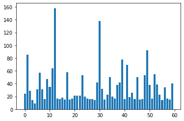

```python
# label encode the target variable
from collections import Counter
from matplotlib import pyplot
le= preprocessing.LabelEncoder()
le.fit(y)
y = le.fit_transform(y)
# summarize distribution
counter = Counter(y)
for k,v in counter.items():
    per = v / len(y) * 100
    print('Class=%d, n=%d (%.3f%%)' % (k, v, per))
# plot the distribution
pyplot.bar(counter.keys(), counter.values())
pyplot.show()
```

From the distribution of each class label of Disease column, we can see disease categories are not balanced.

```python
le_name_mapping1 = dict(zip(le.transform(le.classes_), le.classes_))
# creating pickle file to use flask
pickle.dump(le_name_mapping1,open("disease_name.pkl","wb"))
```

```python
# list of categorical variables
#from numpy import array
cat_list = X[['Intensity', 'Severity','Symptoms','Gender']]
```

#### Implementing One hot encoder to create binary features for each categorical variables.

```python
from sklearn.preprocessing import OneHotEncoder
#enc = OneHotEncoder(handle_unknown='ignore')
enc = OneHotEncoder(sparse =False)

cat_enc = enc.fit_transform(cat_list)
column_name = enc.get_feature_names_out(['Intensity', 'Severity','Symptoms','Gender'])
enc_df = pd.DataFrame(cat_enc, columns= column_name)

new_X = X.join(enc_df)
new_X

new_X = new_X.drop(['Intensity', 'Severity','Symptoms','Gender'],axis=1)
#print(new_X)
```

### **Trying to balance dataset using oversampling method**

```
Class=35, n=158 (1.667%)
Class=29, n=158 (1.667%)
Class=32, n=158 (1.667%)
Class=12, n=158 (1.667%)
Class=36, n=158 (1.667%)
Class=19, n=158 (1.667%)
Class=33, n=158 (1.667%)
Class=52, n=158 (1.667%)
Class=45, n=158 (1.667%)
Class=18, n=158 (1.667%)
Class=16, n=158 (1.667%)
Class=49, n=158 (1.667%)
Class=34, n=158 (1.667%)
Class=46, n=158 (1.667%)
Class=1, n=158 (1.667%)
Class=43, n=158 (1.667%)
Class=41, n=158 (1.667%)
Class=30, n=158 (1.667%)
Class=0, n=158 (1.667%)
Class=56, n=158 (1.667%)
Class=57, n=158 (1.667%)
Class=26, n=158 (1.667%)
Class=7, n=158 (1.667%)
Class=17, n=158 (1.667%)
Class=5, n=158 (1.667%)
Class=15, n=158 (1.667%)
Class=48, n=158 (1.667%)
Class=11, n=158 (1.667%)
Class=37, n=158 (1.667%)
Class=22, n=158 (1.667%)
Class=42, n=158 (1.667%)
Class=23, n=158 (1.667%)
Class=28, n=158 (1.667%)
Class=58, n=158 (1.667%)
Class=4, n=158 (1.667%)
Class=53, n=158 (1.667%)
Class=9, n=158 (1.667%)
Class=31, n=158 (1.667%)
Class=27, n=158 (1.667%)
Class=3, n=158 (1.667%)
Class=39, n=158 (1.667%)
Class=6, n=158 (1.667%)
Class=14, n=158 (1.667%)
Class=38, n=158 (1.667%)
Class=44, n=158 (1.667%)
Class=24, n=158 (1.667%)
Class=51, n=158 (1.667%)
Class=21, n=158 (1.667%)
Class=59, n=158 (1.667%)
Class=25, n=158 (1.667%)
Class=50, n=158 (1.667%)
Class=10, n=158 (1.667%)
Class=40, n=158 (1.667%)
Class=47, n=158 (1.667%)
Class=13, n=158 (1.667%)
Class=20, n=158 (1.667%)
Class=54, n=158 (1.667%)
Class=2, n=158 (1.667%)
Class=8, n=158 (1.667%)
Class=55, n=158 (1.667%)
```

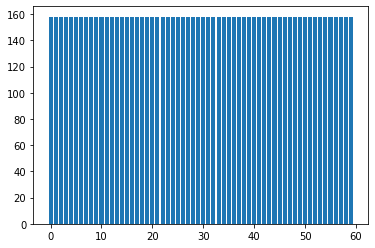

```python
from imblearn.over_sampling import SMOTE

oversample = SMOTE()
X, y = oversample.fit_resample(new_X, y)
# summarize distribution
counter = Counter(y)
for k,v in counter.items():
	per = v / len(y) * 100
	print('Class=%d, n=%d (%.3f%%)' % (k, v, per))
# plot the distribution
pyplot.bar(counter.keys(), counter.values())
pyplot.show() #data set being balanced all the dieases have same % now.
```

We can see each class label of Disease column is balanced now after oversampling the minority class label.

```python
X_list = X.columns
final_X_list=list(X_list)

# creating a pickle file to use for Flask ( which include list of categorical columns name)
pickle.dump(final_X_list,open("list.pkl","wb"))
```

### Train and test split

#### Now its time to split our data into a training set and a test set! The 'Disease' variable is the one that we will try to predict.

```python
X.shape
```

```
(9480, 412)
```

```python
y.shape
```

```
(9480,)
```

```python
#Train and Split with 80/20 ratio
X_train, X_test, y_train, y_test = train_test_split(X, y, random_state = 55, test_size= 0.2)
X_train.shape, X_test.shape, y_train.shape, y_test.shape
```

```
((7584, 412), (1896, 412), (7584,), (1896,))
```

#### Standardaization of the data (used for numerical data)

```python
from sklearn.preprocessing import StandardScaler
sc = StandardScaler()
X_train = sc.fit_transform(X_train)
X_test = sc.transform(X_test)
```

```python
# for future analysis
#mapper = DataFrameMapper([
 #   (numeric_list, StandardScaler()),
 #   (categorial_list_OneHot, OneHotEncoder()),
 #   (categorial_list_LabelEncoder, LabelEncoder())
#])
```

## **Model building**

### Helper function

```python
from sklearn.metrics import confusion_matrix, accuracy_score
# helper function to build the model
def model_perf_v1(model,X_train, X_val, y_train, y_val):
    print("Accuracy on training set:")
    pred = model.predict(X_train)
    accuracy_train = (accuracy_score(y_true = y_train, y_pred = pred))
    print(accuracy_train)
    print("Accuracy on testing set:")
    pred_t = model.predict(X_val)
    accuracy_test = (accuracy_score(y_true = y_val, y_pred = pred_t))
    print(accuracy_test)
    return accuracy_train, accuracy_test
```

```python
# helper function to create a comparision plot
def plot(dicOne,dicTwo,metricName,label1,label2):
    '''bar plot'''
    x = np.arange(len(dicOne))

    width = 0.3
    metric_name = metricName
    val_dicOne = [v for v in dicOne.values()]
    val_dicTwo = [v for v in dicTwo.values()] #getting values from dictionarys
    plt.ylabel(label1+'-'+label2)
    plt.bar(x - 0.17, val_dicOne, width, label=label1) #adding space
    plt.bar(x + 0.17, val_dicTwo, width, label=label2)

    plt.xticks(ticks=x, labels=dicOne.keys(),
               rotation=45) #rotating ticks as they wont fit properly
    _ = plt.legend()
```

#### Initiate all the classifier from the sklearn library. Keep all parameters with their default values. ( without specifing anything)

```python
# intializing empty dictionary
accuracy_test_1={}
accuracy_train_1={}
grid_dict_simple = {0: 'DecisionTree',1: 'RandomForest',2:'GradientBoosting',3:'XGboost'}
```

```python
# Building Decision Tree classifier Model
dt = DecisionTreeClassifier()
dt.fit(X_train, y_train)
accuracy_train, accuracy_test= model_perf_v1(dt,X_train,X_test,y_train,y_test)
accuracy_train_1[grid_dict_simple[0]]= accuracy_train
accuracy_test_1[grid_dict_simple[0]]= accuracy_test
```

```
Accuracy on training set:
1.0
Accuracy on testing set:
0.9604430379746836
```

[figure not shown]

```python
from sklearn import tree
# plotting the decision tree
fig = plt.figure(figsize = (15,10))
_ = tree.plot_tree(decision_tree = dt, filled = True)
```

```python
# Building Random Forest Model
rf = RandomForestClassifier()
rf.fit(X_train, y_train)
accuracy_train, accuracy_test= model_perf_v1(rf,X_train,X_test,y_train,y_test)
accuracy_train_1[grid_dict_simple[1]]= accuracy_train
accuracy_test_1[grid_dict_simple[1]]= accuracy_test
```

```
Accuracy on training set:
1.0
Accuracy on testing set:
0.9161392405063291
```

```python
# Building Gradient Boost Model
grb = GradientBoostingClassifier()
grb.fit(X_train, y_train)
accuracy_train, accuracy_test= model_perf_v1(grb,X_train,X_test,y_train,y_test)
accuracy_train_1[grid_dict_simple[2]]= accuracy_train
accuracy_test_1[grid_dict_simple[2]]=accuracy_test
```

```
Accuracy on training set:
0.9993407172995781
Accuracy on testing set:
0.8734177215189873
```

```python
import xgboost as xgb
# Building XGBoost Model
xg_reg = xgb.XGBClassifier()
xg_reg.fit(X_train, y_train)
accuracy_train, accuracy_test= model_perf_v1(xg_reg,X_train,X_test,y_train,y_test)
accuracy_train_1[grid_dict_simple[3]]= accuracy_train
accuracy_test_1[grid_dict_simple[3]]=accuracy_test
```

```
[20:17:16] WARNING: C:/Users/Administrator/workspace/xgboost-win64_release_1.5.1/src/learner.cc:1115: Starting in XGBoost 1.3.0, the default evaluation metric used with the objective 'multi:softprob' was changed from 'merror' to 'mlogloss'. Explicitly set eval_metric if you'd like to restore the old…
Accuracy on training set:
1.0
Accuracy on testing set:
0.9678270042194093
```

**Comparing the Accuracy of Train and Test set of these models:**

```python
accuracy_train_1
```

```
{'DecisionTree': 1.0,
 'RandomForest': 1.0,
 'GradientBoosting': 0.9993407172995781,
 'XGboost': 1.0}
```

```python
accuracy_test_1
```

```
{'DecisionTree': 0.9604430379746836,
 'RandomForest': 0.9161392405063291,
 'GradientBoosting': 0.8734177215189873,
 'XGboost': 0.9678270042194093}
```

We built our models using Decision Tree Classifier, Random Forest, Gradiant Boosting, and XGBoost method, but XGBoost model gave us the rest accuract compare to other models.

### **Comparison barplot for default classifiers**

```
ACCURACY for default classifiers
```

[figure not shown]

```python
print("ACCURACY for default classifiers")
plot(accuracy_train_1,accuracy_test_1 ,'Accuracy','Training','Testing')
```

### **PCA Analysis**

```python
accuracy_train_pca={}
accuracy_test_pca={}
```

```python
pca = PCA(n_components=None)
pca.fit(X_train)
print(np.cumsum(pca.explained_variance_ratio_))
```

[output not shown]

[output cut: 14 more lines]

```
 0.84573884 0.84796259 0.85018515 0.8524058  0.85462399 0.85683929
 0.85905296 0.86126487 0.86347357 0.86568116 0.86788438 0.87008644
 0.87228773 0.87448659 0.87668194 0.87887504 0.88106622 0.88325518
 0.88544223 0.88762615 0.8898076  0.89198842 0.89416372 0.89633673
 0.89850828 0.90067748 0.90284547 0.90500999 0.90717237 0.90933078
 0.91148668 0.91363744 0.91578623 0.91793136 0.92007459 0.9222164
 0.92435537 0.92649055 0.92862392 0.93075314 0.93287774 0.93499629
 0.93710783 0.9392158  0.94132271 0.94342286 0.94551534 0.94760318
 0.94969012 0.95177035 0.95383895 0.9559052  0.95796436 0.96001478
 0.96205368 0.96408101 0.96610627 0.968128   0.97014818 0.97216278
 0.97416879 0.97616766 0.97816407 0.98015397 0.98212938 0.98407794
 0.9859062  0.98772865 0.98933086 0.99089039 0.99240791 0.99385274
 0.99521075 0.99651188 0.99775331 0.99890037 1.         1.
 1.         1.         1.         1.         1.         1.
 1.         1.         1.         1.        ]
```

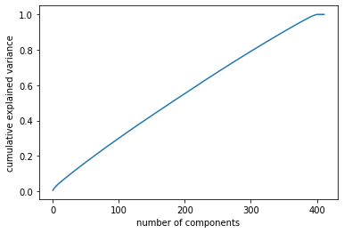

```python
plt.plot(np.cumsum(pca.explained_variance_ratio_))
plt.xlabel('number of components')
plt.ylabel('cumulative explained variance')
```

From above plot we didnot see clear cutoff point so we are using PCA with 95% variance captured.

```python
from sklearn.decomposition import PCA
pca = PCA(0.95)
X_train_pca = pca.fit_transform(X_train)
X_test_pca = pca.transform(X_test)
```

```python
print(np.cumsum(pca.explained_variance_ratio_))
```

[output not shown]

[output cut: 8 more lines]

```
 0.76404601 0.76635428 0.76865798 0.77096104 0.77326209 0.77556162
 0.77786032 0.78015552 0.78244976 0.78474049 0.78702936 0.78931547
 0.79159898 0.79388169 0.79616226 0.7984424  0.80071879 0.80299231
 0.80526407 0.80753222 0.80979787 0.81206219 0.81432395 0.8165851
 0.81884448 0.82110107 0.82335657 0.82560839 0.82785646 0.83010125
 0.83234331 0.83458176 0.83681867 0.83905208 0.84128364 0.84351274
 0.84573884 0.84796259 0.85018515 0.8524058  0.85462399 0.85683929
 0.85905296 0.86126487 0.86347357 0.86568116 0.86788438 0.87008644
 0.87228773 0.87448659 0.87668194 0.87887504 0.88106622 0.88325518
 0.88544223 0.88762615 0.8898076  0.89198842 0.89416372 0.89633673
 0.89850828 0.90067748 0.90284547 0.90500999 0.90717237 0.90933078
 0.91148668 0.91363744 0.91578623 0.91793136 0.92007459 0.9222164
 0.92435537 0.92649055 0.92862392 0.93075314 0.93287774 0.93499629
 0.93710783 0.9392158  0.94132271 0.94342286 0.94551534 0.94760318
 0.94969012 0.95177035]
```

```python
dt = DecisionTreeClassifier()
# fitting the model
dt.fit(X_train_pca, y_train)
accuracy_train, accuracy_test= model_perf_v1(dt,X_train_pca,X_test_pca,y_train,y_test)
accuracy_train_pca[grid_dict_simple[0]]= accuracy_train
accuracy_test_pca[grid_dict_simple[0]]=accuracy_test
```

```
Accuracy on training set:
1.0
Accuracy on testing set:
0.5474683544303798
```

```python
rf = RandomForestClassifier()
#fitting the model
rf.fit(X_train_pca, y_train)
accuracy_train, accuracy_test= model_perf_v1(rf,X_train_pca,X_test_pca,y_train,y_test)
accuracy_train_pca[grid_dict_simple[1]]= accuracy_train
accuracy_test_pca[grid_dict_simple[1]]=accuracy_test
```

```
Accuracy on training set:
1.0
Accuracy on testing set:
0.6529535864978903
```

### Comparison barplot of classifier using PCA

```
ACCURACY for PCA
```

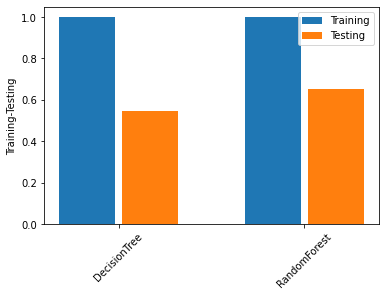

```python
print("ACCURACY for PCA")
plot(accuracy_train_pca,accuracy_test_pca,'Accuracy','Training','Testing')
```

PCA is not useful in this dataset, as we have multilabel of disease classes and Symptoms we got after one hotencoding is almost 409 individual columns. We can see Classifier model is not performing using PCA.

### **Performing grid search by hyperparameters tunning**

```python
# Helper function for grid search
def grid_search_helper():

    pipeline1 = Pipeline((
    ('clf', DecisionTreeClassifier()),
    ))

    pipeline2 = Pipeline((
    ('clf', xgb.XGBClassifier()),
    ))

    parameters1 = {
    'clf__min_samples_split': [2,3, 5,6],
    'clf__max_depth': list(range(1,10))
    }

    parameters2 ={
    'clf__n_estimators':[25],
    'clf__max_leaves':[7,8],
    'clf__gamma': [0],
    'clf__max_depth': list(range(5,7))
    }

    pars = [parameters1, parameters2]
    pips = [pipeline1, pipeline2]

    print("starting Gridsearch")
    dict_best_params ={}
    for i in range(len(pars)):
        print(pars[i])
        print(pips[i])
        gs = GridSearchCV(pips[i], pars[i], cv= 5, n_jobs=-1)
        gs.fit(X_train, y_train)
        print("finished Gridsearch\n")
        #print(gs.best_estimator_)
        dict_best_params[i]= gs.best_estimator_
    return dict_best_params
```

```python
best_params_dict = grid_search_helper()
```

```
starting Gridsearch
{'clf__min_samples_split': [2, 3, 5, 6], 'clf__max_depth': [1, 2, 3, 4, 5, 6, 7, 8, 9]}
Pipeline(steps=(('clf', DecisionTreeClassifier()),))
finished Gridsearch

{'clf__n_estimators': [25], 'clf__max_leaves': [7, 8], 'clf__gamma': [0], 'clf__max_depth': [5, 6]}
Pipeline(steps=(('clf', XGBClassifier()),))
finished Gridsearch
```

#### **Hyper parameter Tunning for decision tree classification**

```python
accuracy_train, accuracy_test = model_perf_v1(best_params_dict[0],X_train,X_test,y_train,y_test)
```

```
Accuracy on training set:
0.5171413502109705
Accuracy on testing set:
0.505801687763713
```

#### **Hyper parameter tunning for XGBoost**

```python
accuracy_train, accuracy_test = model_perf_v1(best_params_dict[1],X_train,X_test,y_train,y_test)
```

```
Accuracy on training set:
0.9771888185654009
Accuracy on testing set:
0.9404008438818565
```

#### Features importance for XGboost classifier model

```python
best_params_dict[1].named_steps["clf"].feature_importances_
```

[output not shown]

[output cut: 49 more lines]

```
       2.58035082e-02, 6.77137941e-05, 0.00000000e+00, 2.27428949e-03,
       0.00000000e+00, 4.56810836e-03, 1.68487208e-03, 3.09344241e-03,
       0.00000000e+00, 0.00000000e+00, 0.00000000e+00, 2.27409927e-03,
       0.00000000e+00, 1.30016136e-03, 0.00000000e+00, 1.01757292e-02,
       2.09682132e-03, 1.12282287e-03, 0.00000000e+00, 0.00000000e+00,
       4.85356012e-03, 2.01328136e-02, 0.00000000e+00, 0.00000000e+00,
       9.26749781e-03, 0.00000000e+00, 7.99983914e-04, 0.00000000e+00,
       1.33611425e-03, 4.68269340e-04, 2.82474631e-03, 3.59536556e-04,
       0.00000000e+00, 5.04431839e-04, 7.14455033e-04, 2.02721171e-02,
       0.00000000e+00, 2.60739820e-03, 6.89566461e-03, 2.91255681e-04,
       7.54860835e-03, 1.36684929e-03, 3.89220571e-04, 1.80538394e-03,
       0.00000000e+00, 2.22499343e-03, 8.79077590e-04, 2.96794297e-03,
       8.72071076e-04, 5.15701389e-03, 5.12968190e-03, 1.21708761e-03,
       1.26535224e-03, 2.96936976e-03, 9.38615703e-04, 0.00000000e+00],
      dtype=float32)
```

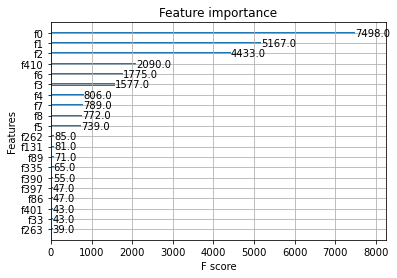

```python
from xgboost import plot_importance
plot_importance(xg_reg, max_num_features = 20)
pyplot.show()
```

```python
listcol = X.columns
listcol[:412]
```

```
Index(['Weight', 'Height', 'Age', 'Intensity_high', 'Intensity_low',
       'Intensity_medium', 'Severity_high', 'Severity_low', 'Severity_medium',
       'Symptoms_Heberden's node',
       ...
       'Symptoms_weepiness', 'Symptoms_weight gain', 'Symptoms_welt',
       'Symptoms_wheelchair bound', 'Symptoms_wheezing', 'Symptoms_withdraw',
       'Symptoms_worry', 'Symptoms_yellow sputum', 'Gender_female',
       'Gender_male'],
      dtype='object', length=412)
```

[figure not shown]

```python
feature_important = xg_reg.get_booster().get_score(importance_type ='weight')
#keys = list(feature_important.keys())
keys = listcol[:233]
values = list(feature_important.values())
data5 = pd.DataFrame(data= values, index=keys, columns=['score']).sort_values(by="score", ascending =False)
data5.nlargest(15, columns="score").plot(kind='barh', figsize=(20,10))
```

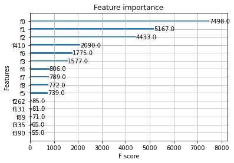

```python
from xgboost import plot_importance
plot_importance(xg_reg, max_num_features = 15)
pyplot.show()
```

#### **Conclusion**

# Choosing final model as XGBoost(hyparameter), as it gives almost same accuracy

```python
pickle.dump(best_params_dict[1], open("final_update_1.pkl", "wb"))
```

# Flask Poject

Passing the our best model(XGBoost) to Flask. The Flask framework will help us to send and recieve responses from patients.

**Passing and loading the ML model using Flask's Pickle library**

```python
#model = pickle.load(open('final_update.pkl', 'rb'))
final_X_list = pickle.load(open('list.pkl', 'rb'))
disease_mapping_names =  pickle.load(open("disease_name.pkl","rb"))
hmodel = pickle.load(open('final_update_1.pkl', 'rb'))

#initilaize the  Flask class with a variable called app
app=Flask(__name__,template_folder='template')
#app = Flask(__name__)

@app.route('/home')
def home():

    return render_template('index.html')


@app.route('/predict', methods=['POST'])
def predict():
    data1 = request.form['a']
    data2 = request.form['b']
    data3 = request.form['c']
    data4 = request.form['d']
    data5 = request.form['e']
    data6 = request.form['f']
    data7 = request.form['g']

    Data = pd.DataFrame({'Age':[data1], 'Gender': [data2], 'Height': [data3], 'Weight': [data4], 'Intensity': [data5],'Severity':[data6], 'Symptoms':[data7]})

    #enc = OneHotEncoder(handle_unknown='ignore')

    enc_cat = enc.transform(Data[['Intensity', 'Severity', 'Symptoms', 'Gender']])
    column_names = enc.get_feature_names_out(['Intensity', 'Severity','Symptoms', 'Gender'])
    enc_df = pd.DataFrame(enc_cat, columns= column_names)

    df = Data.join(enc_df)
    df = df.drop(['Intensity', 'Severity','Symptoms', 'Gender'],axis=1)


    for col in final_X_list:
        if col in df.columns:
            print(col)
        else:
            df[col] = 0
    #sc = StandardScaler()
    df = sc.transform(df)
    print(df)

    #print(df)
    pred = hmodel.predict(df)
    print(pred)

    dis =''
    for key in disease_mapping_names:
        if key == pred[0]:
            dis = disease_mapping_names[key]
            break

    return render_template('index.html', data='You may suffer from {}. Please visit to hospital for further diagnosis and take care of yourself.'.format(dis))

if __name__ == "__main__":
    app.run(debug=False)
```

```
 * Serving Flask app "__main__" (lazy loading)
 * Environment: production
   WARNING: This is a development server. Do not use it in a production deployment.
   Use a production WSGI server instead.
 * Debug mode: off
```

```
 * Running on http://127.0.0.1:5000/ (Press CTRL+C to quit)
127.0.0.1 - - [16/Mar/2022 14:10:50] "GET / HTTP/1.1" 404 -
127.0.0.1 - - [16/Mar/2022 14:10:53] "GET /p HTTP/1.1" 404 -
127.0.0.1 - - [16/Mar/2022 14:10:54] "GET /home HTTP/1.1" 200 -
```

[output not shown]

[output cut: 460 more lines]

[output not shown]

```
[4]
```

[output not shown]

[output cut: 461 more lines]

[output not shown]

### Contributions:

Shruti : Contributed to data cleaning and preprocessing section (dropping insignificant variables, combining similar symptoms & diseases), Tried model building using Kmeans & Kmodes clustering, Flask implementation.

Pinki : Contributed to data cleaning and preprocessing section, implementing multiple correspondence analysis, building a auto model and Flask implementation.

Umiama :Contributed to data cleaning and preprocessing section, Explantory Analysis, building models and Azure Cloud modeling building in Desginer and Auto ML.

Thank you!!

```python
#%%shell
#jupyter nbconvert --to html CapstoneProject_ML_DiseasePrediction_Final_Group4.ipynb
```

```
[NbConvertApp] Converting notebook CapstoneProject_ML_DiseasePrediction_Final_Group4.ipynb to html
[NbConvertApp] Writing 3798787 bytes to CapstoneProject_ML_DiseasePrediction_Final_Group4.html
```